# 112524031

任務 D：實作機器學習演算法（截止日期：12 月 2 日週一）

在此任務中，您將探索幾種機器學習演算法，以獲得監督和無監督學習的實務經驗。請按照以下說明完成任務的每個部分。 指示 觀看影片教學 首先觀看我們提供的影片教學。這些影片介紹了機器學習中的關鍵概念，並提供如何有效應用不同演算法的範例。

下載資料集 下載此資料集： data.csv 此資料集包含有關學生人口統計、學業成績和其他因素的資訊。有關每個功能的完整描述，請參閱 此處提供的資料集詳細資訊。

任務要求 使用 K 最近鄰 (KNN) 演算法 提示：使用提供的功能來訓練和測試您的模型，並旨在預測 Target 變數。

使用線性迴歸演算法

提示：應用線性迴歸來預測資料集中的連續變量，例如 Admission Grade 或 GPA。您也可以使用適當的指標（例如，平均絕對誤差、R 平方）來評估模型的效能。 （獎勵）使用無監督學習 技巧：嘗試根據特定特徵（例如人口統計或學術背景）對資料進行聚類並解釋所得的組別。

對於每項任務，提供評估指標並創建結果的可視化！

下載資料集 下載此資料集： data.csv 此資料集包含有關學生人口統計、學業成績和其他因素的資訊。有關每個功能的完整描述，請參閱 此處提供的資料集詳細資訊。

任務要求 使用 K 最近鄰 (KNN) 演算法 提示：使用提供的功能來訓練和測試您的模型，並旨在預測 Target 變數。

使用線性迴歸演算法

提示：應用線性迴歸來預測資料集中的連續變量，例如 Admission Grade 或 GPA。您也可以使用適當的指標（例如，平均絕對誤差、R 平方）來評估模型的效能。 （獎勵）使用無監督學習 技巧：嘗試根據特定特徵（例如人口統計或學術背景）對資料進行聚類並解釋所得的組別。

對於每項任務，提供評估指標並創建結果的可視化！ Task D: Implementing Machine Learning Algorithms (deadline: 12/2 Mon)

In this task, you will explore several machine learning algorithms to gain hands-on experience with both supervised and unsupervised learning. Follow the instructions below to complete each part of the task. Instructions Watch the Video Tutorials Begin by watching the video tutorials we have provided. These videos introduce key concepts in machine learning and provide examples of how to apply different algorithms effectively.

Download the Dataset Download this dataset: data.csv The dataset contains information on students' demographics, academic performance, and other factors. For a full description of each feature, refer to the dataset details provided here.

Task Requirements Using K-Nearest Neighbors (KNN) Algorithm Tips: Use the features provided to train and test your model, and aim to predict the Target variable.

Using Linear Regression Algorithm

Tips: Apply linear regression to predict a continuous variable in the dataset, such as Admission Grade or GPA. You can also evaluate the model's performance using appropriate metrics (e.g., Mean Absolute Error, R-squared). (Bonus) Using Unsupervised Learning Tips: Attempt to cluster the data based on specific features (e.g., demographics or academic background) and interpret the resulting groups.

For each task, provide evaluation metrics and create the visualization of your results!

## 1.KNN

```python
import pandas as pd
import numpy as np
from sklearn.model_selection import train_test_split
from sklearn.preprocessing import MinMaxScaler
from sklearn.neighbors import KNeighborsClassifier
from sklearn.metrics import accuracy_score, classification_report, confusion_matrix
```

```python
df = pd.read_csv('data.csv', delimiter=';')
df.head()
```

|  | Marital status | Application mode | Application order | Course | Daytime/evening attendance\t | Previous qualification | Previous qualification (grade) | Nacionality | Mother's qualification | Father's qualification | ... | Curricular units 2nd sem (credited) | Curricular units 2nd sem (enrolled) | Curricular units 2nd sem (evaluations) | Curricular units 2nd sem (approved) | Curricular units 2nd sem (grade) | Curricular units 2nd sem (without evaluations) | Unemployment rate | Inflation rate | GDP | Target |
| --- | --- | --- | --- | --- | --- | --- | --- | --- | --- | --- | --- | --- | --- | --- | --- | --- | --- | --- | --- | --- | --- |
| 0 | 1 | 17 | 5 | 171 | 1 | 1 | 122.0 | 1 | 19 | 12 | ... | 0 | 0 | 0 | 0 | 0.000000 | 0 | 10.8 | 1.4 | 1.74 | Dropout |
| 1 | 1 | 15 | 1 | 9254 | 1 | 1 | 160.0 | 1 | 1 | 3 | ... | 0 | 6 | 6 | 6 | 13.666667 | 0 | 13.9 | -0.3 | 0.79 | Graduate |
| 2 | 1 | 1 | 5 | 9070 | 1 | 1 | 122.0 | 1 | 37 | 37 | ... | 0 | 6 | 0 | 0 | 0.000000 | 0 | 10.8 | 1.4 | 1.74 | Dropout |
| 3 | 1 | 17 | 2 | 9773 | 1 | 1 | 122.0 | 1 | 38 | 37 | ... | 0 | 6 | 10 | 5 | 12.400000 | 0 | 9.4 | -0.8 | -3.12 | Graduate |
| 4 | 2 | 39 | 1 | 8014 | 0 | 1 | 100.0 | 1 | 37 | 38 | ... | 0 | 6 | 6 | 6 | 13.000000 | 0 | 13.9 | -0.3 | 0.79 | Graduate |

5 rows × 37 columns

```python
# 查看資料的基本資訊，包括每列的名稱、資料類型及遺漏值數量
print(df.info())
```

```
<class 'pandas.core.frame.DataFrame'>
RangeIndex: 4424 entries, 0 to 4423
Data columns (total 37 columns):
 #   Column                                          Non-Null Count  Dtype
---  ------                                          --------------  -----
 0   Marital status                                  4424 non-null   int64
 1   Application mode                                4424 non-null   int64
 2   Application order                               4424 non-null   int64
 3   Course                                          4424 non-null   int64
 4   Daytime/evening attendance	                     4424 non-null   int64
 5   Previous qualification                          4424 non-null   int64
 6   Previous qualification (grade)                  4424 non-null   float64
 7   Nacionality                                     4424 non-null   int64
 8   Mother's qualification                          4424 non-null   int64
 9   Father's qualification                          4424 non-null   int64
```

[output cut: 30 more lines]

```python
# 檢視統計摘要，僅適用於數值型資料
print(df.describe())
```

```
       Marital status  Application mode  Application order       Course  \
count     4424.000000       4424.000000        4424.000000  4424.000000
mean         1.178571         18.669078           1.727848  8856.642631
std          0.605747         17.484682           1.313793  2063.566416
min          1.000000          1.000000           0.000000    33.000000
25%          1.000000          1.000000           1.000000  9085.000000
50%          1.000000         17.000000           1.000000  9238.000000
75%          1.000000         39.000000           2.000000  9556.000000
max          6.000000         57.000000           9.000000  9991.000000

       Daytime/evening attendance\t  Previous qualification  \
count                   4424.000000             4424.000000
mean                       0.890823                4.577758
std                        0.311897               10.216592
min                        0.000000                1.000000
25%                        1.000000                1.000000
50%                        1.000000                1.000000
75%                        1.000000                1.000000
max                        1.000000               43.000000

       Previous qualification (grade)  Nacionality  Mother's qualification  \
count                     4424.000000  4424.000000             4424.000000
mean                       132.613314     1.873192               19.561935
std                         13.188332     6.914514               15.603186
min                         95.000000     1.000000                1.000000
25%                        125.000000     1.000000                2.000000
50%                        133.100000     1.000000               19.000000
75%                        140.000000     1.000000               37.000000
max                        190.000000   109.000000               44.000000

       Father's qualification  ...  \
count             4424.000000  ...
mean                22.275316  ...
std                 15.343108  ...
min                  1.000000  ...
25%                  3.000000  ...
50%                 19.000000  ...
75%                 37.000000  ...
max                 44.000000  ...

```

[output cut: 56 more lines]

```
50%                                          0.000000          11.100000
75%                                          0.000000          13.900000
max                                         12.000000          16.200000

       Inflation rate          GDP
count     4424.000000  4424.000000
mean         1.228029     0.001969
std          1.382711     2.269935
min         -0.800000    -4.060000
25%          0.300000    -1.700000
50%          1.400000     0.320000
75%          2.600000     1.790000
max          3.700000     3.510000

[8 rows x 36 columns]
```

```python
# 檢查欄位名稱
print(df.columns)
```

```
Index(['Marital status', 'Application mode', 'Application order', 'Course',
       'Daytime/evening attendance\t', 'Previous qualification',
       'Previous qualification (grade)', 'Nacionality',
       'Mother's qualification', 'Father's qualification',
       'Mother's occupation', 'Father's occupation', 'Admission grade',
       'Displaced', 'Educational special needs', 'Debtor',
       'Tuition fees up to date', 'Gender', 'Scholarship holder',
       'Age at enrollment', 'International',
       'Curricular units 1st sem (credited)',
       'Curricular units 1st sem (enrolled)',
       'Curricular units 1st sem (evaluations)',
       'Curricular units 1st sem (approved)',
       'Curricular units 1st sem (grade)',
       'Curricular units 1st sem (without evaluations)',
       'Curricular units 2nd sem (credited)',
       'Curricular units 2nd sem (enrolled)',
       'Curricular units 2nd sem (evaluations)',
       'Curricular units 2nd sem (approved)',
       'Curricular units 2nd sem (grade)',
       'Curricular units 2nd sem (without evaluations)', 'Unemployment rate',
       'Inflation rate', 'GDP', 'Target'],
      dtype='object')
```

```python
print(df.isnull().sum())
```

```
Marital status                                    0
Application mode                                  0
Application order                                 0
Course                                            0
Daytime/evening attendance\t                      0
Previous qualification                            0
Previous qualification (grade)                    0
Nacionality                                       0
Mother's qualification                            0
Father's qualification                            0
Mother's occupation                               0
Father's occupation                               0
Admission grade                                   0
Displaced                                         0
Educational special needs                         0
Debtor                                            0
Tuition fees up to date                           0
Gender                                            0
Scholarship holder                                0
Age at enrollment                                 0
International                                     0
Curricular units 1st sem (credited)               0
Curricular units 1st sem (enrolled)               0
Curricular units 1st sem (evaluations)            0
Curricular units 1st sem (approved)               0
Curricular units 1st sem (grade)                  0
Curricular units 1st sem (without evaluations)    0
Curricular units 2nd sem (credited)               0
Curricular units 2nd sem (enrolled)               0
Curricular units 2nd sem (evaluations)            0
Curricular units 2nd sem (approved)               0
Curricular units 2nd sem (grade)                  0
Curricular units 2nd sem (without evaluations)    0
Unemployment rate                                 0
Inflation rate                                    0
GDP                                               0
Target                                            0
dtype: int64
```

```python
df
```

|  | Marital status | Application mode | Application order | Course | Daytime/evening attendance\t | Previous qualification | Previous qualification (grade) | Nacionality | Mother's qualification | Father's qualification | ... | Curricular units 2nd sem (credited) | Curricular units 2nd sem (enrolled) | Curricular units 2nd sem (evaluations) | Curricular units 2nd sem (approved) | Curricular units 2nd sem (grade) | Curricular units 2nd sem (without evaluations) | Unemployment rate | Inflation rate | GDP | Target |
| --- | --- | --- | --- | --- | --- | --- | --- | --- | --- | --- | --- | --- | --- | --- | --- | --- | --- | --- | --- | --- | --- |
| 0 | 1 | 17 | 5 | 171 | 1 | 1 | 122.0 | 1 | 19 | 12 | ... | 0 | 0 | 0 | 0 | 0.000000 | 0 | 10.8 | 1.4 | 1.74 | Dropout |
| 1 | 1 | 15 | 1 | 9254 | 1 | 1 | 160.0 | 1 | 1 | 3 | ... | 0 | 6 | 6 | 6 | 13.666667 | 0 | 13.9 | -0.3 | 0.79 | Graduate |
| 2 | 1 | 1 | 5 | 9070 | 1 | 1 | 122.0 | 1 | 37 | 37 | ... | 0 | 6 | 0 | 0 | 0.000000 | 0 | 10.8 | 1.4 | 1.74 | Dropout |
| 3 | 1 | 17 | 2 | 9773 | 1 | 1 | 122.0 | 1 | 38 | 37 | ... | 0 | 6 | 10 | 5 | 12.400000 | 0 | 9.4 | -0.8 | -3.12 | Graduate |
| 4 | 2 | 39 | 1 | 8014 | 0 | 1 | 100.0 | 1 | 37 | 38 | ... | 0 | 6 | 6 | 6 | 13.000000 | 0 | 13.9 | -0.3 | 0.79 | Graduate |
| ... | ... | ... | ... | ... | ... | ... | ... | ... | ... | ... | ... | ... | ... | ... | ... | ... | ... | ... | ... | ... | ... |
| 4419 | 1 | 1 | 6 | 9773 | 1 | 1 | 125.0 | 1 | 1 | 1 | ... | 0 | 6 | 8 | 5 | 12.666667 | 0 | 15.5 | 2.8 | -4.06 | Graduate |
| 4420 | 1 | 1 | 2 | 9773 | 1 | 1 | 120.0 | 105 | 1 | 1 | ... | 0 | 6 | 6 | 2 | 11.000000 | 0 | 11.1 | 0.6 | 2.02 | Dropout |
| 4421 | 1 | 1 | 1 | 9500 | 1 | 1 | 154.0 | 1 | 37 | 37 | ... | 0 | 8 | 9 | 1 | 13.500000 | 0 | 13.9 | -0.3 | 0.79 | Dropout |
| 4422 | 1 | 1 | 1 | 9147 | 1 | 1 | 180.0 | 1 | 37 | 37 | ... | 0 | 5 | 6 | 5 | 12.000000 | 0 | 9.4 | -0.8 | -3.12 | Graduate |
| 4423 | 1 | 10 | 1 | 9773 | 1 | 1 | 152.0 | 22 | 38 | 37 | ... | 0 | 6 | 6 | 6 | 13.000000 | 0 | 12.7 | 3.7 | -1.70 | Graduate |

4424 rows × 37 columns

```python
type(df.Target)
```

```
pandas.core.series.Series
```

```python
from sklearn.preprocessing import LabelEncoder
# 將類別型的資料轉換為數值型資料
le = LabelEncoder()
df['Target'] = le.fit_transform(df['Target'])
df
```

|  | Marital status | Application mode | Application order | Course | Daytime/evening attendance\t | Previous qualification | Previous qualification (grade) | Nacionality | Mother's qualification | Father's qualification | ... | Curricular units 2nd sem (credited) | Curricular units 2nd sem (enrolled) | Curricular units 2nd sem (evaluations) | Curricular units 2nd sem (approved) | Curricular units 2nd sem (grade) | Curricular units 2nd sem (without evaluations) | Unemployment rate | Inflation rate | GDP | Target |
| --- | --- | --- | --- | --- | --- | --- | --- | --- | --- | --- | --- | --- | --- | --- | --- | --- | --- | --- | --- | --- | --- |
| 0 | 1 | 17 | 5 | 171 | 1 | 1 | 122.0 | 1 | 19 | 12 | ... | 0 | 0 | 0 | 0 | 0.000000 | 0 | 10.8 | 1.4 | 1.74 | 0 |
| 1 | 1 | 15 | 1 | 9254 | 1 | 1 | 160.0 | 1 | 1 | 3 | ... | 0 | 6 | 6 | 6 | 13.666667 | 0 | 13.9 | -0.3 | 0.79 | 2 |
| 2 | 1 | 1 | 5 | 9070 | 1 | 1 | 122.0 | 1 | 37 | 37 | ... | 0 | 6 | 0 | 0 | 0.000000 | 0 | 10.8 | 1.4 | 1.74 | 0 |
| 3 | 1 | 17 | 2 | 9773 | 1 | 1 | 122.0 | 1 | 38 | 37 | ... | 0 | 6 | 10 | 5 | 12.400000 | 0 | 9.4 | -0.8 | -3.12 | 2 |
| 4 | 2 | 39 | 1 | 8014 | 0 | 1 | 100.0 | 1 | 37 | 38 | ... | 0 | 6 | 6 | 6 | 13.000000 | 0 | 13.9 | -0.3 | 0.79 | 2 |
| ... | ... | ... | ... | ... | ... | ... | ... | ... | ... | ... | ... | ... | ... | ... | ... | ... | ... | ... | ... | ... | ... |
| 4419 | 1 | 1 | 6 | 9773 | 1 | 1 | 125.0 | 1 | 1 | 1 | ... | 0 | 6 | 8 | 5 | 12.666667 | 0 | 15.5 | 2.8 | -4.06 | 2 |
| 4420 | 1 | 1 | 2 | 9773 | 1 | 1 | 120.0 | 105 | 1 | 1 | ... | 0 | 6 | 6 | 2 | 11.000000 | 0 | 11.1 | 0.6 | 2.02 | 0 |
| 4421 | 1 | 1 | 1 | 9500 | 1 | 1 | 154.0 | 1 | 37 | 37 | ... | 0 | 8 | 9 | 1 | 13.500000 | 0 | 13.9 | -0.3 | 0.79 | 0 |
| 4422 | 1 | 1 | 1 | 9147 | 1 | 1 | 180.0 | 1 | 37 | 37 | ... | 0 | 5 | 6 | 5 | 12.000000 | 0 | 9.4 | -0.8 | -3.12 | 2 |
| 4423 | 1 | 10 | 1 | 9773 | 1 | 1 | 152.0 | 22 | 38 | 37 | ... | 0 | 6 | 6 | 6 | 13.000000 | 0 | 12.7 | 3.7 | -1.70 | 2 |

4424 rows × 37 columns

```python
from sklearn.model_selection import train_test_split

# 假設 'Target' 是目標變數，其他欄位是特徵
X = df.drop('Target', axis=1)  # 特徵
y = df['Target']               # 目標

# 分割資料集
X_train, X_test, y_train, y_test = train_test_split(X, y, test_size=0.2, random_state=88)

print("訓練集大小:", X_train.shape)
print("測試集大小:", X_test.shape)
```

```
訓練集大小: (3539, 36)
測試集大小: (885, 36)
```

```python
scaler = MinMaxScaler()

# 正規化訓練集和測試集
X_train = scaler.fit_transform(X_train)
X_test = scaler.transform(X_test)

print("正規化後的訓練集：")
X_train
```

```
正規化後的訓練集：
```

```
array([[0.2       , 0.67857143, 0.11111111, ..., 0.37209302, 0.48888889,
        0.7661823 ],
       [0.        , 0.67857143, 0.11111111, ..., 0.20930233, 0.        ,
        0.12417437],
       [0.2       , 0.67857143, 0.22222222, ..., 0.20930233, 0.        ,
        0.12417437],
       ...,
       [0.        , 0.        , 0.11111111, ..., 0.55813953, 0.28888889,
        0.77278732],
       [0.2       , 0.        , 0.11111111, ..., 0.59302326, 1.        ,
        0.31175694],
       [0.        , 0.        , 0.11111111, ..., 0.        , 0.75555556,
        0.57859974]])
```

```python
from sklearn.model_selection import cross_val_score
# 嘗試不同的 K 值，找到最佳 K
k_values = range(1, 21)
scores = []
for k in k_values:
    knn = KNeighborsClassifier(n_neighbors=k)
    score = np.mean(cross_val_score(knn, X_train_knn, y_train_knn, cv=5))  # 5 折交叉驗證
    scores.append(score)

# 找到最佳 K
best_k = k_values[np.argmax(scores)]
print("最佳 K 值:", best_k)
```

```
最佳 K 值: 15
```

```python
knn = KNeighborsClassifier(n_neighbors=15)
knn.fit(X_train, y_train)

y_pred = knn.predict(X_test)
print("準確率:", accuracy_score(y_test, y_pred))
print("分類報告:\n", classification_report(y_test, y_pred))
```

```
準確率: 0.6813559322033899
分類報告:
               precision    recall  f1-score   support

           0       0.80      0.66      0.73       279
           1       0.35      0.11      0.16       168
           2       0.66      0.91      0.77       438

    accuracy                           0.68       885
   macro avg       0.60      0.56      0.55       885
weighted avg       0.65      0.68      0.64       885
```

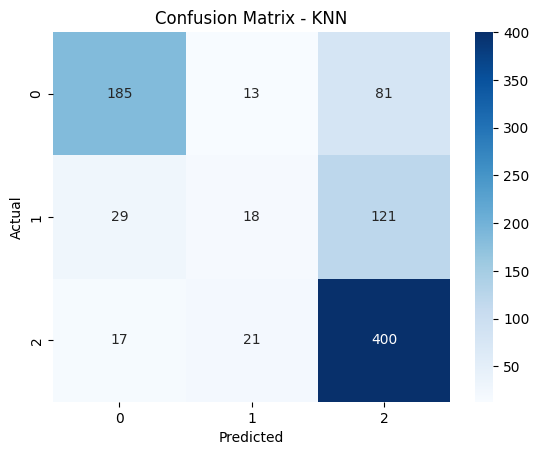

```python
import seaborn as sns
import matplotlib.pyplot as plt
cm = confusion_matrix(y_test, y_pred)
sns.heatmap(cm, annot=True, fmt='d', cmap='Blues')
plt.xlabel('Predicted')
plt.ylabel('Actual')
plt.title('Confusion Matrix - KNN')
plt.show()
```

```python
# 計算相關性
correlation_matrix = df.corr()
print(correlation_matrix['Target'].sort_values(ascending=False))
```

```
Target                                            1.000000
Curricular units 2nd sem (approved)               0.624157
Curricular units 2nd sem (grade)                  0.566827
Curricular units 1st sem (approved)               0.529123
Curricular units 1st sem (grade)                  0.485207
Tuition fees up to date                           0.409827
Scholarship holder                                0.297595
Curricular units 2nd sem (enrolled)               0.175847
Curricular units 1st sem (enrolled)               0.155974
Admission grade                                   0.120889
Displaced                                         0.113986
Previous qualification (grade)                    0.103764
Curricular units 2nd sem (evaluations)            0.092721
Application order                                 0.089791
Daytime/evening attendance\t                      0.075107
Curricular units 2nd sem (credited)               0.054004
Curricular units 1st sem (credited)               0.048150
Curricular units 1st sem (evaluations)            0.044362
GDP                                               0.044135
Course                                            0.034219
Unemployment rate                                 0.008627
International                                     0.003934
Father's qualification                           -0.001393
Father's occupation                              -0.001899
Mother's occupation                              -0.005629
Educational special needs                        -0.007353
Nacionality                                      -0.014801
Inflation rate                                   -0.026874
Mother's qualification                           -0.043178
Previous qualification                           -0.056039
Curricular units 1st sem (without evaluations)   -0.068702
Marital status                                   -0.089804
Curricular units 2nd sem (without evaluations)   -0.094028
Application mode                                 -0.221747
Gender                                           -0.229270
Debtor                                           -0.240999
Age at enrollment                                -0.243438
Name: Target, dtype: float64
```

```python
# 優化模型
features_knn = ['Curricular units 2nd sem (approved)', 'Curricular units 2nd sem (grade)',
    'Curricular units 1st sem (approved)']
x_knn = df[features_knn]
y_knn = df['Target']
x_knn
```

|  | Curricular units 2nd sem (approved) | Curricular units 2nd sem (grade) | Curricular units 1st sem (approved) |
| --- | --- | --- | --- |
| 0 | 0 | 0.000000 | 0 |
| 1 | 6 | 13.666667 | 6 |
| 2 | 0 | 0.000000 | 0 |
| 3 | 5 | 12.400000 | 6 |
| 4 | 6 | 13.000000 | 5 |
| ... | ... | ... | ... |
| 4419 | 5 | 12.666667 | 5 |
| 4420 | 2 | 11.000000 | 6 |
| 4421 | 1 | 13.500000 | 7 |
| 4422 | 5 | 12.000000 | 5 |
| 4423 | 6 | 13.000000 | 6 |

4424 rows × 3 columns

```python
from sklearn.preprocessing import StandardScaler
# 標準化數據
scaler = StandardScaler()
x_knn_scaled = scaler.fit_transform(x_knn)
x_knn_scaled
```

```
array([[-1.47152688, -1.96348862, -1.52125739],
       [ 0.51890369,  0.65956171,  0.41804989],
       [-1.47152688, -1.96348862, -1.52125739],
       ...,
       [-1.13978845,  0.62757329,  0.74126777],
       [ 0.18716526,  0.33967752,  0.09483201],
       [ 0.51890369,  0.53160803,  0.41804989]])
```

```python
X_train_knn, X_test_knn, y_train_knn, y_test_knn = train_test_split(
    x_knn_scaled, y_knn, test_size=0.2, random_state=88
)
print("訓練集大小:", X_train_knn.shape)
print("測試集大小:", X_test_knn.shape)
```

```
訓練集大小: (3539, 3)
測試集大小: (885, 3)
```

```python
scaler = MinMaxScaler()

# 正規化訓練集和測試集
X_train_knn = scaler.fit_transform(X_train_knn)
X_test_knn = scaler.transform(X_test_knn)

print("正規化後的訓練集：")
X_train_knn
```

```
正規化後的訓練集：
```

```
array([[0.        , 0.        , 0.        ],
       [0.2       , 0.63508065, 0.19230769],
       [0.25      , 0.65483871, 0.19230769],
       ...,
       [0.25      , 0.7       , 0.23076923],
       [0.35      , 0.78467742, 0.26923077],
       [0.        , 0.        , 0.        ]])
```

```python
knn = KNeighborsClassifier(n_neighbors=15)
knn.fit(X_train_knn, y_train_knn)

y_pred_knn = knn.predict(X_test_knn)
print("準確率:", accuracy_score(y_test_knn, y_pred_knn))
print("分類報告:\n", classification_report(y_test_knn, y_pred_knn))
```

```
準確率: 0.6949152542372882
分類報告:
               precision    recall  f1-score   support

           0       0.71      0.68      0.70       279
           1       0.35      0.16      0.22       168
           2       0.74      0.91      0.81       438

    accuracy                           0.69       885
   macro avg       0.60      0.58      0.58       885
weighted avg       0.65      0.69      0.66       885
```

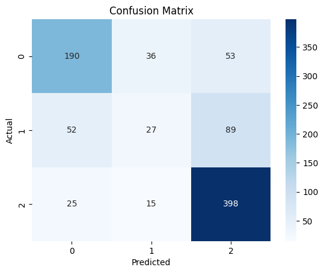

```python
cm = confusion_matrix(y_test_knn, y_pred_knn)
sns.heatmap(cm, annot=True, fmt='d', cmap='Blues')
plt.xlabel('Predicted')
plt.ylabel('Actual')
plt.title('Confusion Matrix')
plt.show()
```

## 2.線性迴歸演算法 Linear Regression

```python
import pandas as pd
from sklearn.linear_model import LinearRegression
from sklearn.model_selection import train_test_split
from sklearn.metrics import mean_squared_error, mean_absolute_error, r2_score
import numpy as np
import matplotlib.pyplot as plt

df
```

|  | Marital status | Application mode | Application order | Course | Daytime/evening attendance\t | Previous qualification | Previous qualification (grade) | Nacionality | Mother's qualification | Father's qualification | ... | Curricular units 2nd sem (credited) | Curricular units 2nd sem (enrolled) | Curricular units 2nd sem (evaluations) | Curricular units 2nd sem (approved) | Curricular units 2nd sem (grade) | Curricular units 2nd sem (without evaluations) | Unemployment rate | Inflation rate | GDP | Target |
| --- | --- | --- | --- | --- | --- | --- | --- | --- | --- | --- | --- | --- | --- | --- | --- | --- | --- | --- | --- | --- | --- |
| 0 | 1 | 17 | 5 | 171 | 1 | 1 | 122.0 | 1 | 19 | 12 | ... | 0 | 0 | 0 | 0 | 0.000000 | 0 | 10.8 | 1.4 | 1.74 | 0 |
| 1 | 1 | 15 | 1 | 9254 | 1 | 1 | 160.0 | 1 | 1 | 3 | ... | 0 | 6 | 6 | 6 | 13.666667 | 0 | 13.9 | -0.3 | 0.79 | 2 |
| 2 | 1 | 1 | 5 | 9070 | 1 | 1 | 122.0 | 1 | 37 | 37 | ... | 0 | 6 | 0 | 0 | 0.000000 | 0 | 10.8 | 1.4 | 1.74 | 0 |
| 3 | 1 | 17 | 2 | 9773 | 1 | 1 | 122.0 | 1 | 38 | 37 | ... | 0 | 6 | 10 | 5 | 12.400000 | 0 | 9.4 | -0.8 | -3.12 | 2 |
| 4 | 2 | 39 | 1 | 8014 | 0 | 1 | 100.0 | 1 | 37 | 38 | ... | 0 | 6 | 6 | 6 | 13.000000 | 0 | 13.9 | -0.3 | 0.79 | 2 |
| ... | ... | ... | ... | ... | ... | ... | ... | ... | ... | ... | ... | ... | ... | ... | ... | ... | ... | ... | ... | ... | ... |
| 4419 | 1 | 1 | 6 | 9773 | 1 | 1 | 125.0 | 1 | 1 | 1 | ... | 0 | 6 | 8 | 5 | 12.666667 | 0 | 15.5 | 2.8 | -4.06 | 2 |
| 4420 | 1 | 1 | 2 | 9773 | 1 | 1 | 120.0 | 105 | 1 | 1 | ... | 0 | 6 | 6 | 2 | 11.000000 | 0 | 11.1 | 0.6 | 2.02 | 0 |
| 4421 | 1 | 1 | 1 | 9500 | 1 | 1 | 154.0 | 1 | 37 | 37 | ... | 0 | 8 | 9 | 1 | 13.500000 | 0 | 13.9 | -0.3 | 0.79 | 0 |
| 4422 | 1 | 1 | 1 | 9147 | 1 | 1 | 180.0 | 1 | 37 | 37 | ... | 0 | 5 | 6 | 5 | 12.000000 | 0 | 9.4 | -0.8 | -3.12 | 2 |
| 4423 | 1 | 10 | 1 | 9773 | 1 | 1 | 152.0 | 22 | 38 | 37 | ... | 0 | 6 | 6 | 6 | 13.000000 | 0 | 12.7 | 3.7 | -1.70 | 2 |

4424 rows × 37 columns

```python
# 計算相關性
correlation_matrix = df.corr()
print(correlation_matrix['Admission grade'].sort_values(ascending=False))
```

```
Admission grade                                   1.000000
Previous qualification (grade)                    0.580444
Previous qualification                            0.184183
Target                                            0.120889
Curricular units 2nd sem (approved)               0.076659
Curricular units 2nd sem (grade)                  0.074402
Curricular units 1st sem (grade)                  0.073868
Curricular units 1st sem (approved)               0.070892
Tuition fees up to date                           0.054132
Curricular units 1st sem (credited)               0.040829
Curricular units 2nd sem (credited)               0.040225
Unemployment rate                                 0.038756
Nacionality                                       0.028176
International                                     0.025274
Scholarship holder                                0.018881
Curricular units 1st sem (without evaluations)    0.009033
Gender                                            0.008315
Daytime/evening attendance\t                      0.007970
Displaced                                        -0.000543
Marital status                                   -0.004771
Curricular units 2nd sem (without evaluations)   -0.013254
Application mode                                 -0.013271
Debtor                                           -0.014423
Educational special needs                        -0.018306
GDP                                              -0.019519
Inflation rate                                   -0.021624
Age at enrollment                                -0.029915
Curricular units 1st sem (enrolled)              -0.033251
Father's occupation                              -0.037733
Mother's occupation                              -0.040186
Curricular units 2nd sem (enrolled)              -0.041878
Father's qualification                           -0.051972
Mother's qualification                           -0.054412
Curricular units 2nd sem (evaluations)           -0.057132
Curricular units 1st sem (evaluations)           -0.072059
Application order                                -0.096930
Course                                           -0.125058
Name: Admission grade, dtype: float64
```

```python
# 用之前成績預測入學成績
X = data['Previous qualification (grade)'].fillna(0).values.reshape(-1, 1)
y = data['Admission grade']  # 目標變數

# print(X.head())
# print(y.head())
print("X 的形狀:", X.shape)
print("y 的形狀:", y.shape)
```

```
X 的形狀: (4424, 1)
y 的形狀: (4424,)
```

```python
X_train, X_test, y_train, y_test = train_test_split(X, y, test_size=0.2, random_state=42)
# 初始化模型
lr = LinearRegression()

# 訓練模型
lr.fit(X_train, y_train)

# 查看模型的權重與截距
print("模型的係數:", lr.coef_)  # 對應兩個特徵的權重
print("模型的截距:", lr.intercept_)
```

```
模型的係數: [0.63033294]
模型的截距: 43.238653476768675
```

```python
# 預測測試集
y_pred = lr.predict(X_test)

# 評估模型
mse = mean_squared_error(y_test, y_pred)
mae = mean_absolute_error(y_test, y_pred)
r2 = r2_score(y_test, y_pred)

print("均方誤差 (MSE):", mse)
print("平均絕對誤差 (MAE):", mae)
print("R 平方 (R²):", r2)
```

```
均方誤差 (MSE): 134.7526674787989
平均絕對誤差 (MAE): 8.23303157299552
R 平方 (R²): 0.35521625140633684
```

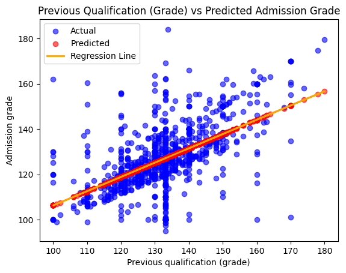

```python
# 實際值 vs 預測值
plt.scatter(X_test, y_test, color='blue', label='Actual', alpha=0.6)
plt.scatter(X_test, y_pred, color='red', label='Predicted', alpha=0.6)

# 繪製回歸線
plt.plot(X_test, y_pred, color='orange', label='Regression Line', linewidth=2)

plt.xlabel('Previous qualification (grade)')
plt.ylabel('Admission grade')
plt.title('Previous Qualification (Grade) vs Predicted Admission Grade')
plt.legend()
plt.show()
```

## 3.非監督 DBSCAN

```python
from sklearn.cluster import DBSCAN
from sklearn.preprocessing import StandardScaler
import matplotlib.pyplot as plt
import numpy as np
```

```python
features = ['Previous qualification (grade)', 'Admission grade']
X = df[features].fillna(0)
scaler = StandardScaler()
X_scaled = scaler.fit_transform(X)
```

```python
# DBSCAN
dbscan = DBSCAN(eps=0.5, min_samples=5)
dbscan.fit(X_scaled)
labels = dbscan.labels_
```

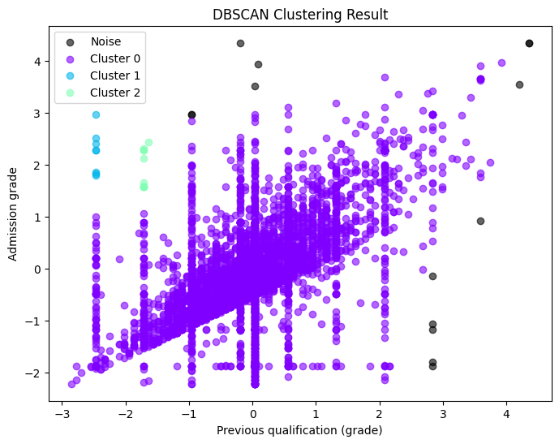

```python
plt.figure(figsize=(8, 6))
unique_labels = np.unique(labels)
for label in unique_labels:
    if label == -1:
        color = 'black'
        label_name = 'Noise'
    else:
        color = plt.cm.rainbow(label / len(unique_labels))
        label_name = f'Cluster {label}'

    plt.scatter(
        X_scaled[labels == label, 0],
        X_scaled[labels == label, 1],
        color=color,
        label=label_name,
        alpha=0.6
    )

plt.xlabel('Previous qualification (grade)')
plt.ylabel('Admission grade')
plt.title('DBSCAN Clustering Result')
plt.legend()
plt.show()
```

## 分群結果解釋

透過學生的學術背景作為分群的特徵，包含 先前學歷成績、入學成績，共分成三群，根據群體特徵分析推斷

- 第一群(0):顯示該群組是數據的主要密度區域。
- 第二、三群(1, 2):是小型群體，可能代表成績特別高或低的學生群體，可能是學校使用不同錄取政策（如特殊招生）。
- 其他(黑點):表明一些數據點與其他群體差異明顯，這可能是成績異常的學生。學術基礎好（X 軸值高）的學生，通常錄取分數（Y 軸值）也高。

Using students' academic background as clustering features, including previous qualification grades and admission grades, the data is divided into three groups. Based on the characteristics of each group, the analysis suggests:

- First Group (0): Represents the primary density area of the data.
- Second and Third Groups (1, 2): These are smaller groups, potentially representing students with particularly high or low grades, which may result from the school applying different admission policies (e.g., special admissions).
- Others (Black Points): Indicate data points that differ significantly from other groups. These may correspond to students with anomalous grades. Students with a strong academic foundation (high X-axis values) are generally associated with higher admission grades (high Y-axis values).